# Лабораторная работа № 6

Реализация SIR в подходе сетей Петри

Куокконен Дарина Андреевна

Российский университет дружбы народов имени Патриса Лумумбы

НФИбд-01-23

2026-08-31

# Вводная часть

## Цель и задачи

**Цель:** построить сеть Петри SIR и сопоставить непрерывное и событийное исполнение.

- создать три позиции и два перехода;
- выполнить базовый опыт, сканирование, анимацию и анализ CSV;
- добавить параметры и стохастические повторы;
- получить и выполнить восемь Julia-блокнотов;
- интегрировать QMD-документацию в отчёт и проверить результаты.

## Закон массового действия

$$\dot S=-\beta SI,\qquad \dot I=\beta SI-\gamma I,\qquad \dot R=\gamma I.$$

$$S+I\longrightarrow 2I,\qquad I\longrightarrow R,\qquad S+I+R=1000.$$

- Начальное состояние: S=990, I=10, R=0.
- Базовые параметры: β=0,3, γ=0,1.
- Закон **βSI без деления на N** сохранён по методичке.

## Структура сети

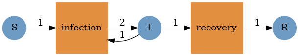

Три позиции, два перехода, сохранение N=1000.

`AlgebraicPetri` → правая часть ОДУ; дуги сети → изменения маркировки SSA.

# Выполнение работы

## Последовательность выполнения

`Julia` → `Literate` → `QMD и IPYNB` → `Quarto` → `Git`

- `make tangle` — восемь комплектов производных форматов;
- `make run` — четыре основных и четыре параметрических сценария;
- `make notebooks` — выполнение блокнотов ядром Julia;
- `make docs` — документация HTML;
- `make test` — структурные и численные проверки.

## Вычислительная среда

- Julia 1.11.9;
- AlgebraicPetri 0.8.11 и Catlab 0.14.17;
- OrdinaryDiffEq 7.8.1, алгоритм Tsit5;
- DataFrames 1.8.2, CSV 0.10.17, Plots 1.41.7;
- DrWatson 2.19.1, Literate 2.21.0 и IJulia 1.34.4.

Точные версии закреплены в `Manifest.toml`.

## Базовый опыт: ОДУ и SSA

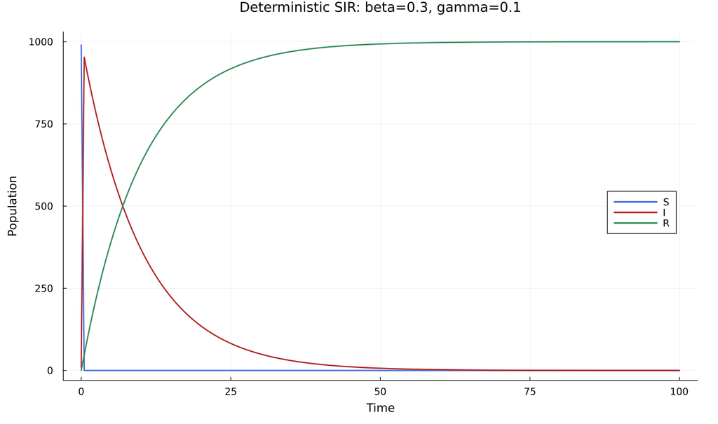

ОДУ: шаг сохранения 0,5.

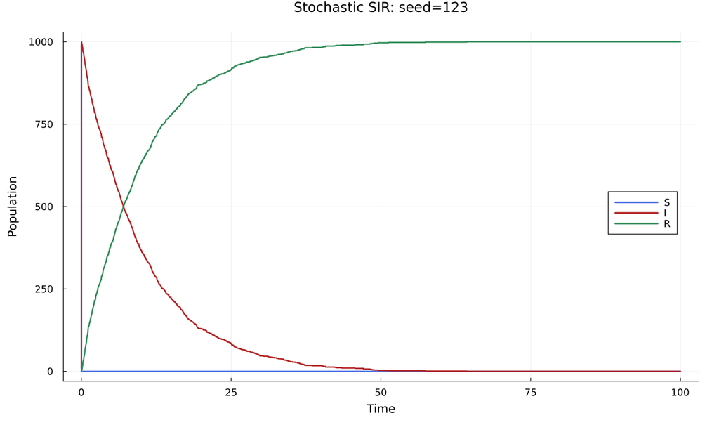

SSA: seed=123, реальные события.

β=0,3; γ=0,1; T=100; N=1000 сохраняется.

## Сетка пропускает ранний пик

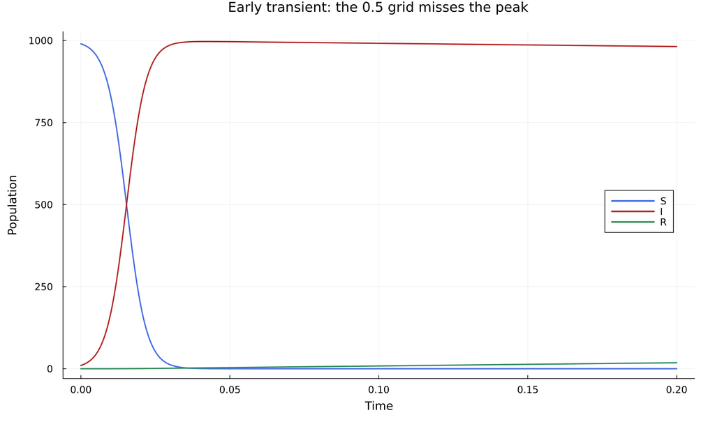

- Уточнённый пик: **997,0012**.
- Его время: **0,042046**.
- Максимум на сетке 0,5: **952,6914**.
- Аналитическая проверка: ошибка менее 10⁻⁸.

## Пятнадцать значений β

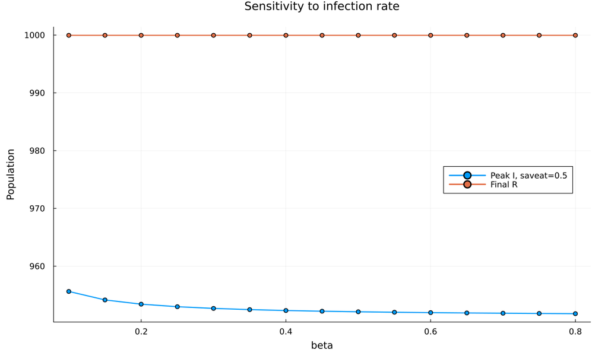

Дискретная метрика на сетке 0,5.

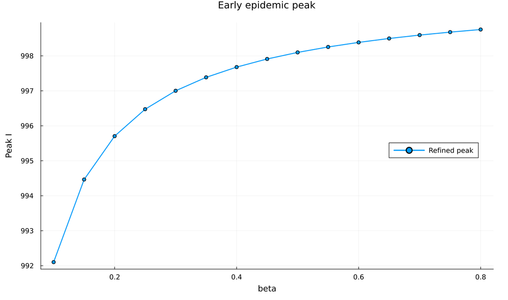

Уточнённая высота пика.

β=0,1:0,05:0,8; γ=0,1. Рост β сдвигает вспышку раньше.

## Анимация маркировок

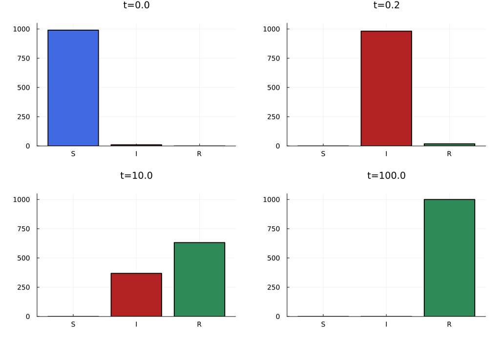

β=0,3; γ=0,1; T=100; шаг 0,2; **501 кадр**, 25 кадров/с.

Три столбца S/I/R, фиксированный масштаб. Контрольные состояния: 0; 0,2; 10; 100.

## Отдельное чтение CSV

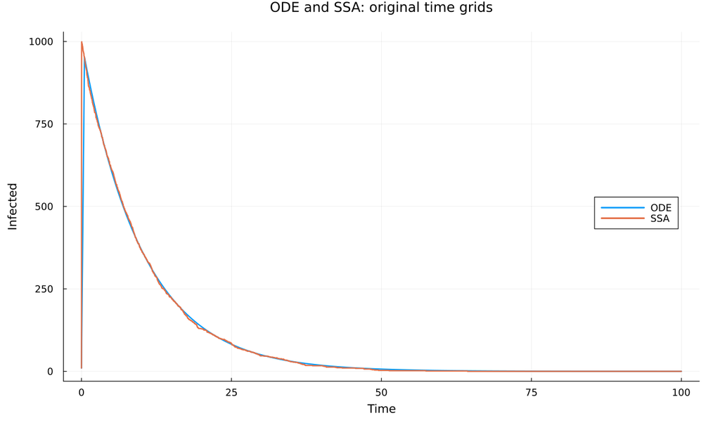

RMSE I на общей сетке: 3,5954.

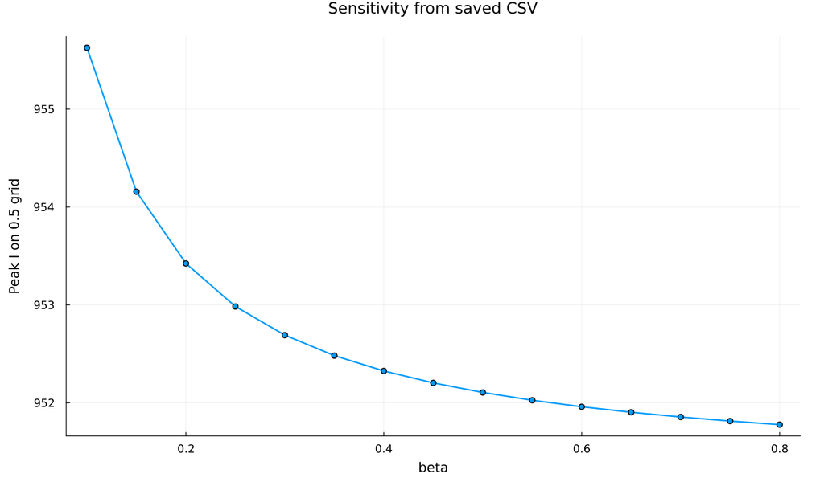

Пик восстановлен из `sir_scan.csv`.

Времена SSA не подменяются сеткой ОДУ; повторной симуляции нет.

# Параметрические варианты

## Девять сочетаний и 180 SSA

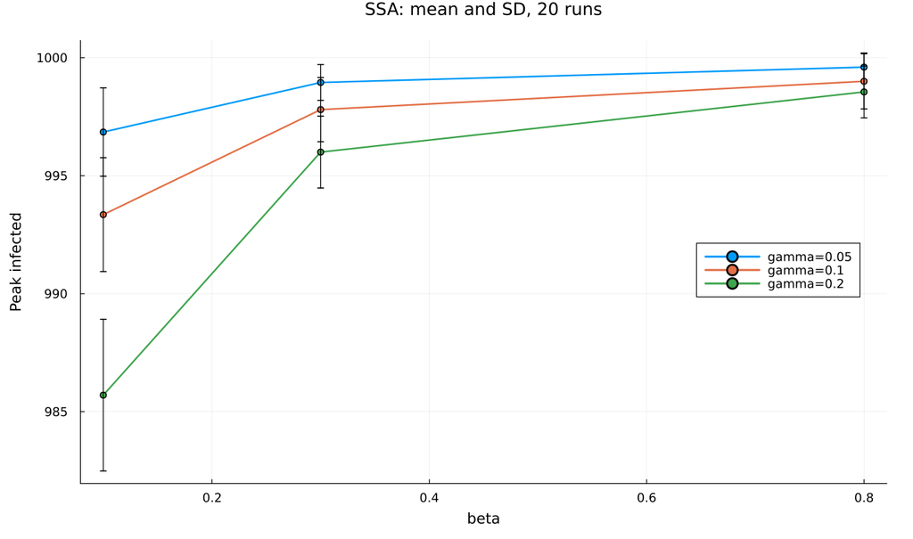

- β={0,1;0,3;0,8};
- γ={0,05;0,1;0,2};
- по 20 повторов;
- 180 разных seed;
- ошибка сохранения N: 0.

Отрезки — стандартные отклонения, не доверительные интервалы.

## Сетка из 45 опытов

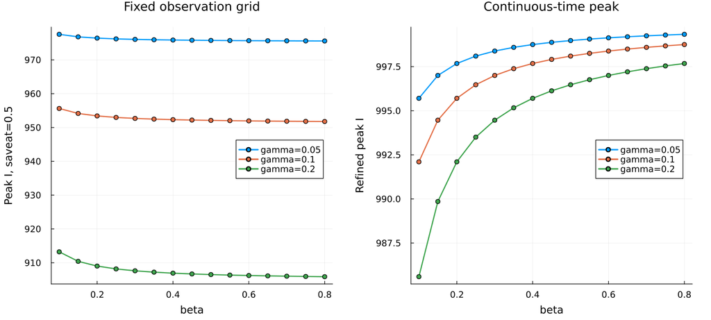

15 исходных β повторены при трёх γ. Дискретный и уточнённый пики сохранены отдельно.

## Три параметрические анимации

- β=0,1;0,3;0,8, γ=0,1;
- горизонт 100, шаг 0,2;
- по 501 кадру, всего **1503 кадра**;
- неизменные три состояния и масштаб;
- траектории CSV и сводная таблица сохранены.

Ранняя вспышка дополнительно исследована на подробном начальном участке.

## Анализ параметрических CSV

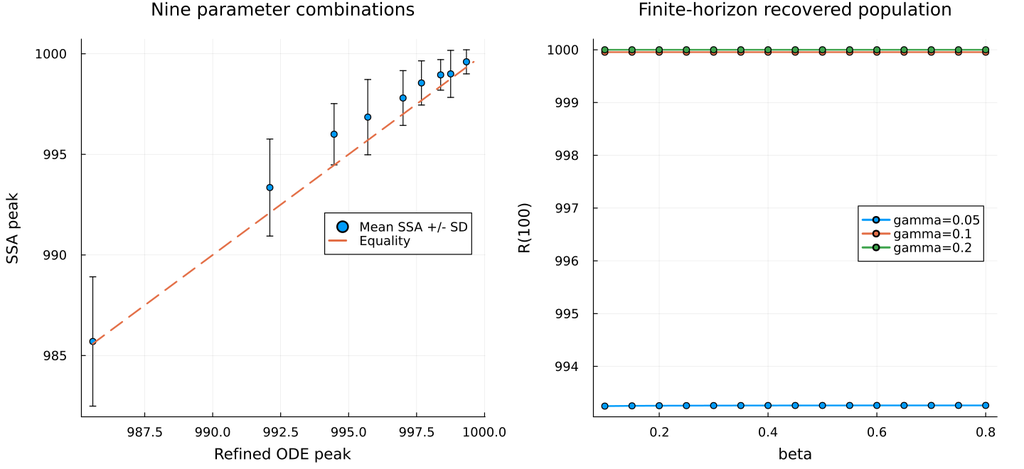

Пять входных таблиц. При γ=0,05 к T=100 остаются заражённые; N сохраняется.

## Восемь выполненных блокнотов

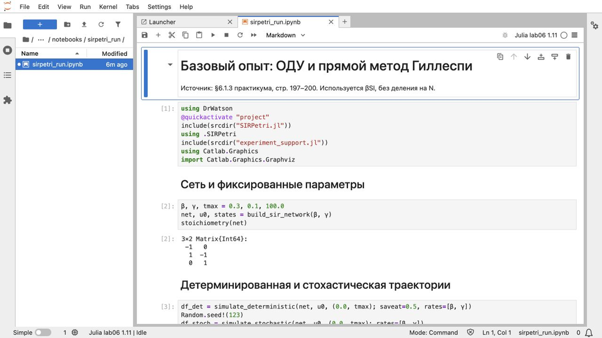

- все ячейки выполнены;
- таблицы, графики и GIF сохранены;
- восемь QMD-фрагментов включены по ходу отчёта.

## Проверки и исправления

**42 теста пройдены.** Сверка: глава 6, стр. 191–207.

- сохранение N, целочисленность SSA и допустимые переходы;
- аналитическая проверка пика ОДУ;
- корректные собственные времена событий SSA;
- βSI сохранён: при β=0,1 эпидемия развивается;
- вместо ошибочного повтора сканирования реализована анимация.

# Выводы

## Итоги

- Одна сеть задаёт ОДУ и дискретные события SSA.
- Выполнены четыре основных и четыре параметрических сценария.
- N=1000 сохраняется; исходники и результаты согласованы.
- Шаг 0,5 скрывает истинный ранний максимум около 997.
- Ограничения модели и исправления примера объяснены явно.

Основа задания: А. В. Королькова, Д. С. Кулябов. «Имитационное моделирование. Практикум», глава 6, стр. 191–207.